# Reign FC Fan Satisfaction Analysis

# Recommendation 1: Beer Garden

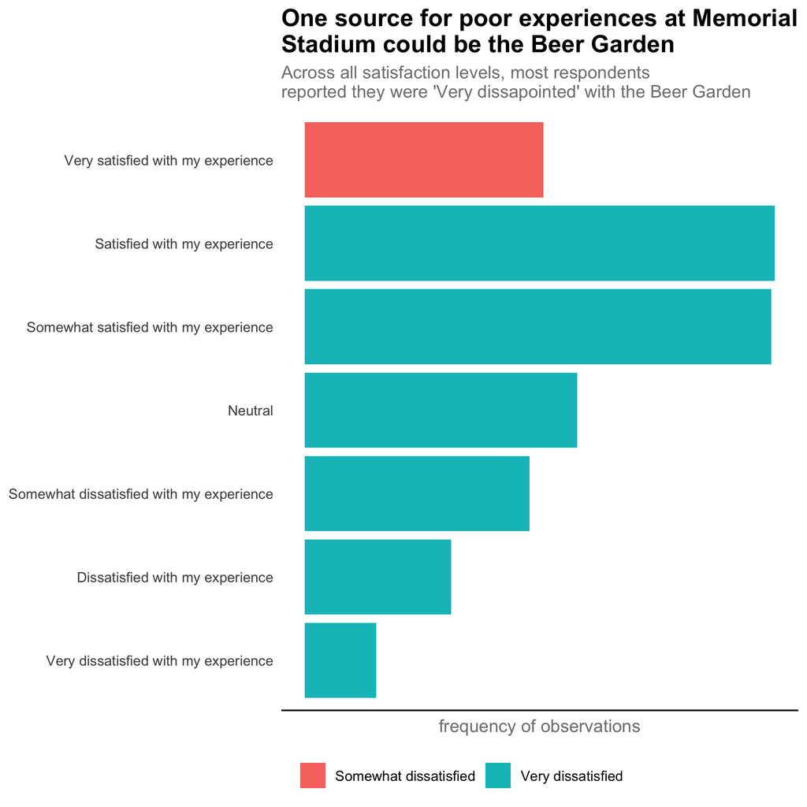

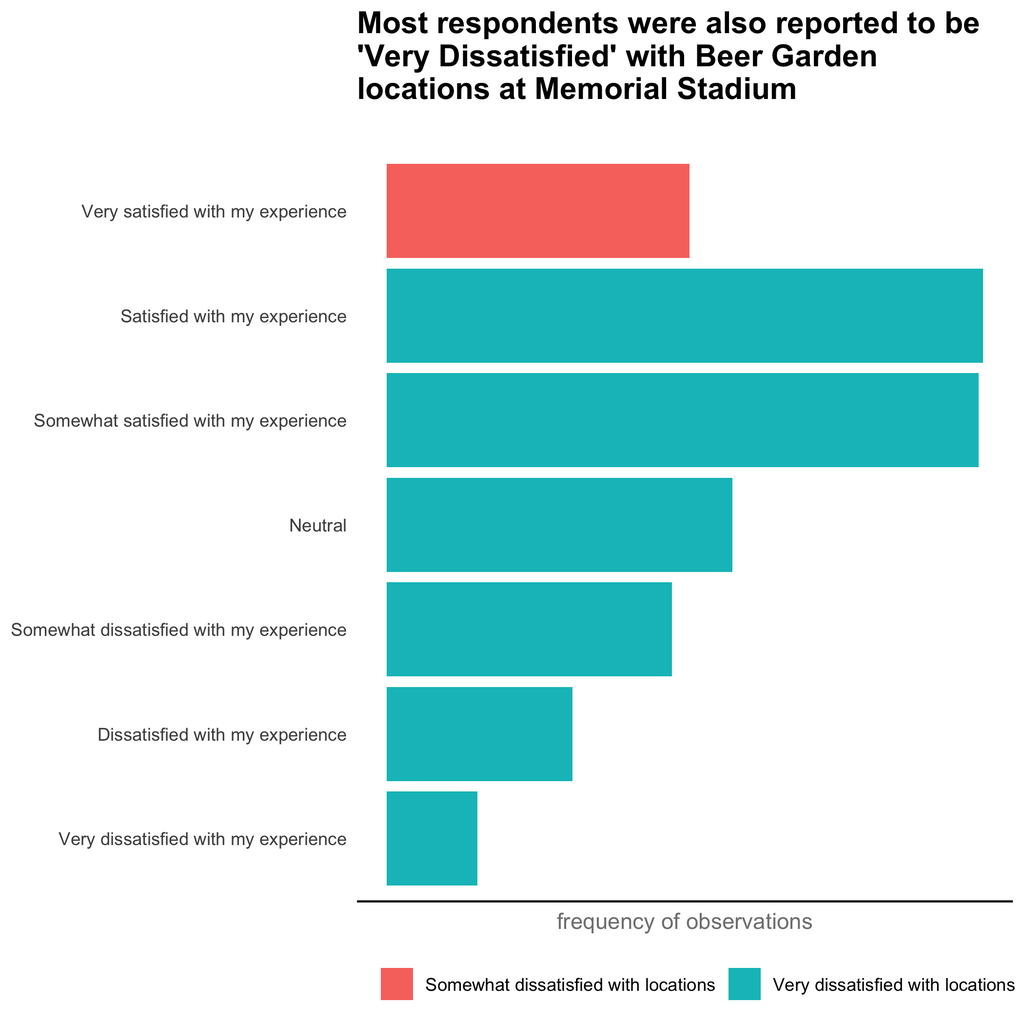

# Recommendation 2: Restroom Cleanliness

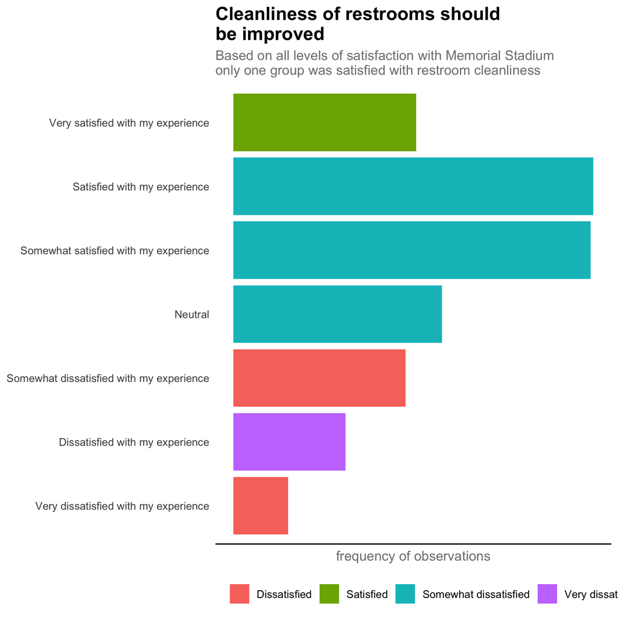

# Conclusion

A fan’s satisfaction with their experience at Reign FC matches attended in Memorial Stadium can be improved by resolving issues stemming from the beer garden itself and the convenience of beer garden locations.

In order to identify the specific issues fans have with the beer garden at Memorial Stadium another survey need to be conducted, but at this time using the results from this initial survey I can tell you that the beer garden is a prominent source of fan dissatisfaction.

Furthermore a fan’s satisfaction with their matchday experience at Memorial Stadium can also be improved by providing cleaner restrooms.